# Titanic case using R

Adapted from https://github.com/wehrley/wehrley.github.io/blob/master/SOUPTONUTS

## Some setup

```r
setwd("/github/kaggle-fiddling/titanic/R")

library(ggplot2)
```

Let us first define a generic function for reading CSV files which handles data types and missing values

```r
# file.path: path of CSV file to be read
# column.types:  type of each column
# missing.types: string corresponding to missing data
readCsvData <- function(file.path, column.types, missing.types) {
  read.csv(file.path, colClasses=column.types, na.strings=missing.types)
}

missing.types <- c("NA", "")
train.column.types <- c('integer',   # PassengerId
                        'factor',    # Survived
                        'factor',    # Pclass
                        'character', # Name
                        'factor',    # Sex
                        'numeric',   # Age
                        'integer',   # SibSp
                        'integer',   # Parch
                        'character', # Ticket
                        'numeric',   # Fare
                        'character', # Cabin
                        'factor'     # Embarked
)
```

## Training data loading

```r
train <- readCsvData("../data/train.csv", train.column.types, missing.types)
```

## Display missing training data with Amelia

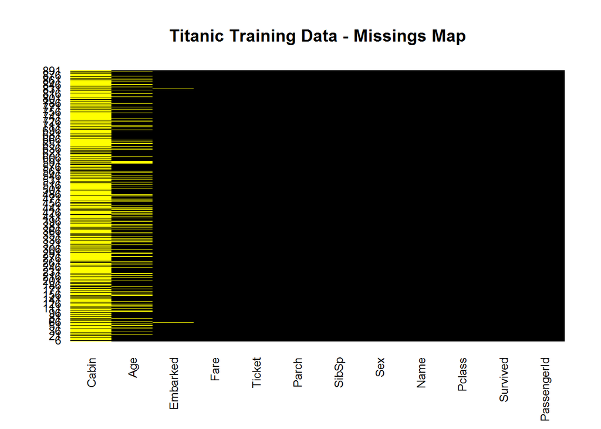

```r
## map missing data byattribute
# install.packages("Amelia")
require(Amelia)
missmap(train, main="Titanic Training Data - Missings Map",
        col=c("yellow", "black"), legend=FALSE)
```

## Test data loading

```r
test.column.types <- train.column.types[-2]     # no Survived column in test.csv
test <- readCsvData("../data/test.csv", test.column.types, missing.types)
```

## Do the same data are missing in test data ?

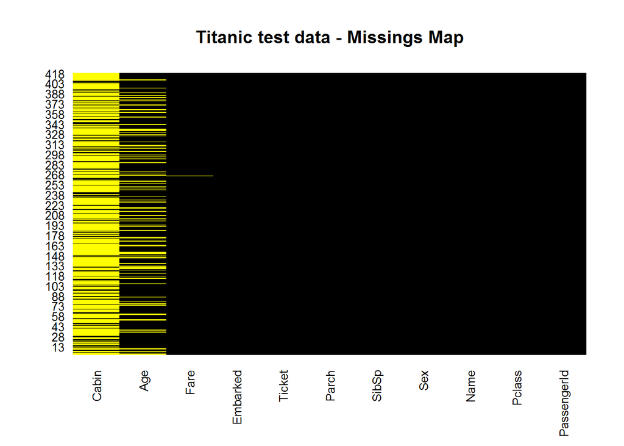

```r
missmap(test, main="Titanic test data - Missings Map",
        col=c("yellow", "black"), legend=FALSE)
```

With a few exceptions (Fare, Embarked), yes.

## General results about passenger survival

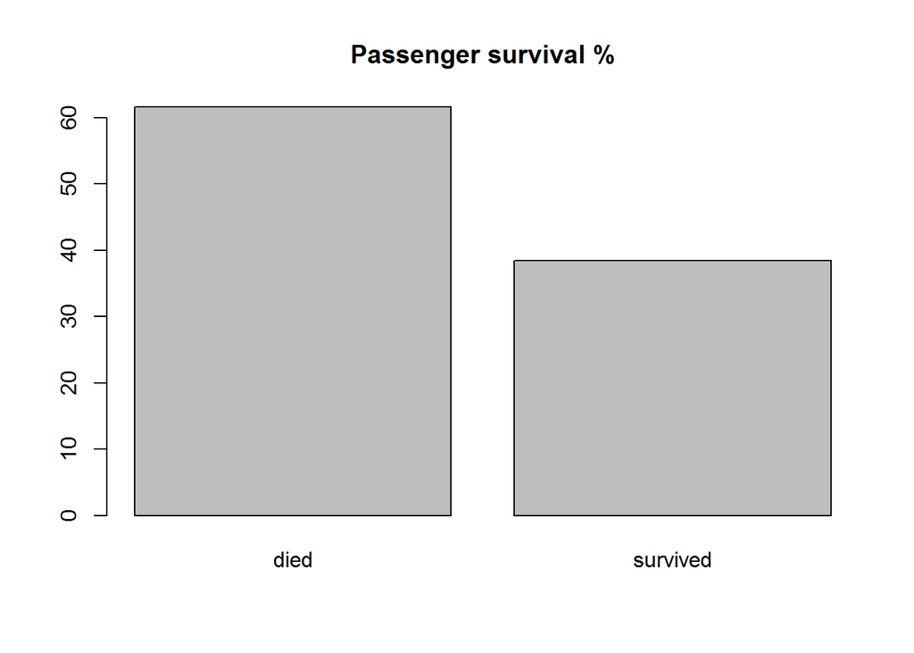

```r
barplot(100*table(train$Survived)/sum(table(train$Survived)), main="Passenger survival %", names.arg=c("died", "survived"))
```

## Impact of sex

Using SQLDF library for querying data (http://www.r-bloggers.com/manipulating-data-frames-using-sqldf-a-brief-overview/ ):

```r
library(sqldf)

surv_sex <- sqldf("select Sex, Survived, count(*) as count from train group by Sex, Survived")
print(surv_sex)
```

```
##      Sex Survived count
## 1 female        0    81
## 2 female        1   233
## 3   male        0   468
## 4   male        1   109
```

Percentages are earsier to read:

```r
transform(surv_sex, percent = signif(ave(count, Sex, FUN = prop.table), digits=2))
```

```
##      Sex Survived count percent
## 1 female        0    81    0.26
## 2 female        1   233    0.74
## 3   male        0   468    0.81
## 4   male        1   109    0.19
```

Many more women survived than men in percentage. Why ? Women and children first. See: - http://www.anesi.com/titanic.htm - http://www.livescience.com/21951-women-children-first-shipwreck-myth.html

Plotting:

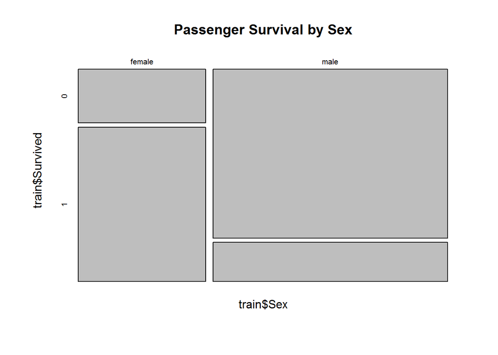

```r
mosaicplot(train$Sex ~ train$Survived, main="Passenger Survival by Sex")
```

For more sexy plotting options, see https://www.kaggle.com/benhamner/titanic/exploratory-analysis-in-r lines 12-14

Another way:

```r
surv_sex2 <- table(train$Survived, train$Sex)
print(surv_sex2)
```

```
##
##     female male
##   0     81  468
##   1    233  109
```

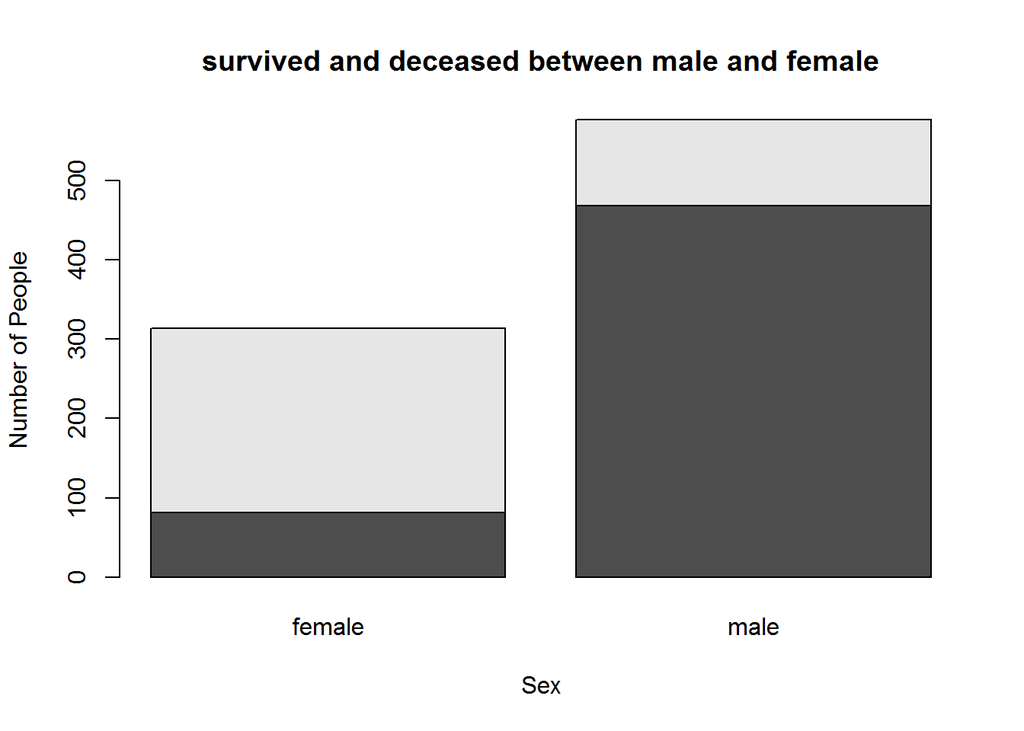

```r
barplot(surv_sex2, xlab = "Sex", ylab = "Number of People", main = "survived and deceased between male and female")
```

## 1st Model based solely on gender

```r
test$Survived <- 0
test$Survived[test$Sex == 'female'] <- 1
```

From http://trevorstephens.com/post/72920580937/titanic-getting-started-with-r-part-2-the, **this model gets 76.555 % predictions right**.

## Submission to Kaggle

```r
submit <- data.frame(PassengerId = test$PassengerId, Survived = test$Survived)
write.csv(submit, file = "genderModel.csv", row.names = FALSE)
```

## Impact of Age

```r
summary(train$Age)
```

```
##    Min. 1st Qu.  Median    Mean 3rd Qu.    Max.    NA's
##    0.42   20.12   28.00   29.70   38.00   80.00     177
```

There are 177 unknown values. What to do with them ? remove the corresponding observations ? infer the age to be the mean value of passengers ? predict the age ?

Let us focus on passengers with a known age

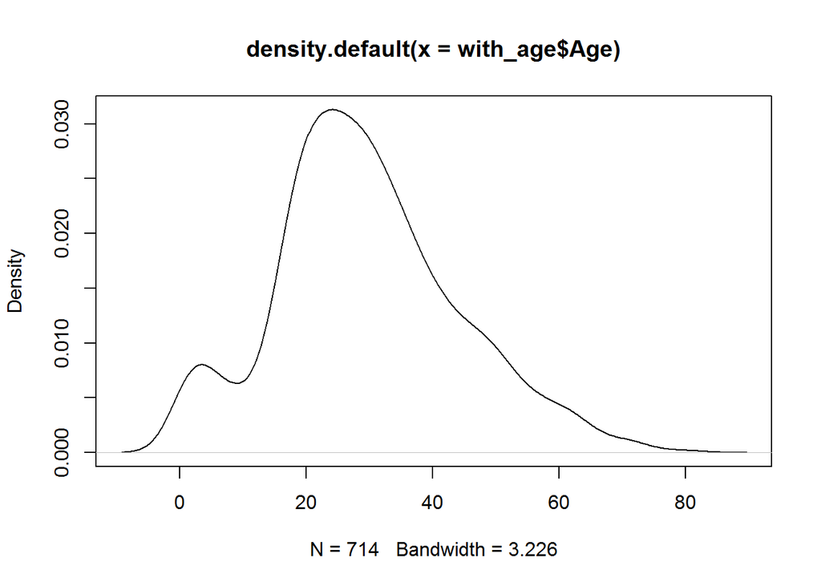

```r
with_age <- subset(train, train$Age != "NA")
plot(density(with_age$Age))
```

How age is affecting survival ?

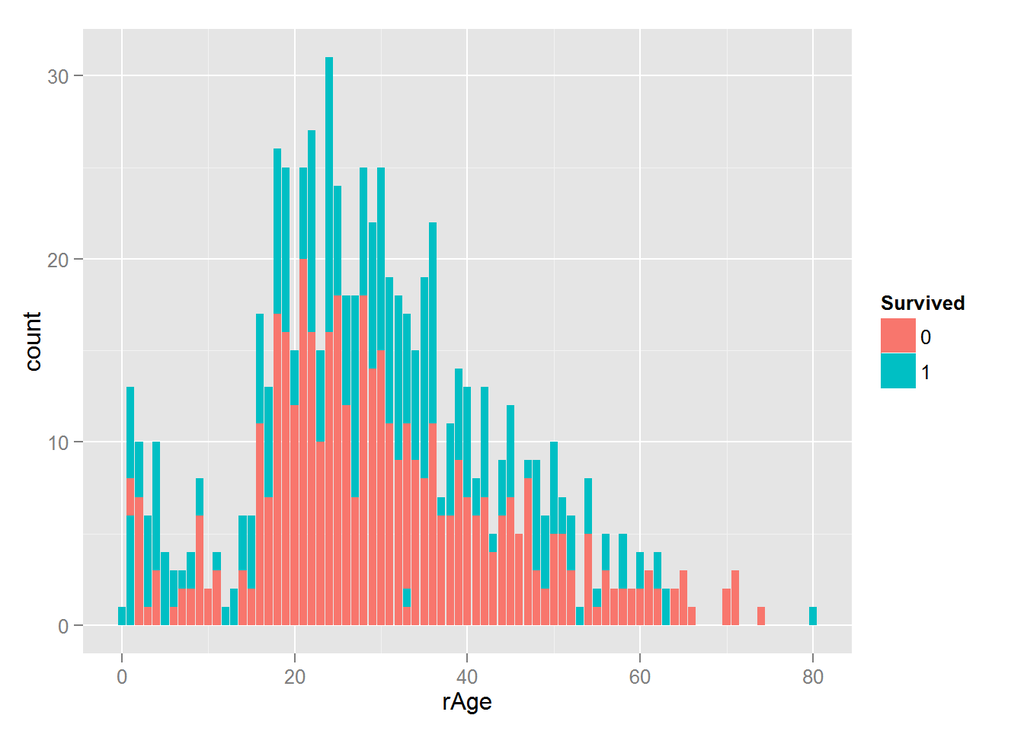

```r
age_count<-sqldf("SELECT round(Age) as rAge, Survived, count(*) AS count FROM with_age GROUP BY age, Survived")
ggplot(data=age_count, aes(x=rAge,y=count,fill=Survived))+geom_bar(stat="identity")
```

There seems to be a change around 15 years. Children with this age or younger survive more than adults. Remember: Women and children first.

From 64 years survival also seems difficult …

This suggests to build three age classes [0;15], [16;63] and [64; inf[

Let us build age classes

```r
train$AgeClass[is.na(train$Age)] <- 'X'
train$AgeClass[! is.na(train$Age)] <- 'A'
train$AgeClass[! is.na(train$Age) & train$Age <= 15] <- 'C'
train$AgeClass[! is.na(train$Age) & train$Age >= 64] <- 'O'
```

Analysis by age class

```r
AgeClassCount <- sqldf("SELECT Sex, AgeClass, Survived, count(*) AS count FROM train GROUP BY Sex, AgeClass, Survived")
print(AgeClassCount)
```

```
##       Sex AgeClass Survived count
## 1  female        A        0    49
## 2  female        A        1   169
## 3  female        C        0    15
## 4  female        C        1    28
## 5  female        X        0    17
## 6  female        X        1    36
## 7    male        A        0   329
## 8    male        A        1    71
## 9    male        C        0    19
## 10   male        C        1    21
## 11   male        O        0    12
## 12   male        O        1     1
## 13   male        X        0   108
## 14   male        X        1    16
```

Further splitting by sex and age class

```r
SexAgeClassCount <- SexAgeClassCount <- sqldf("SELECT Sex, AgeClass, Survived, count(*) AS count FROM train GROUP BY Sex, AgeClass, Survived")
SexAgeClassRate <- transform(SexAgeClassCount, percent = signif(ave(count, AgeClass, FUN = prop.table), digits=2))
print(SexAgeClassRate)
```

```
##       Sex AgeClass Survived count percent
## 1  female        A        0    49   0.079
## 2  female        A        1   169   0.270
## 3  female        C        0    15   0.180
## 4  female        C        1    28   0.340
## 5  female        X        0    17   0.096
## 6  female        X        1    36   0.200
## 7    male        A        0   329   0.530
## 8    male        A        1    71   0.110
## 9    male        C        0    19   0.230
## 10   male        C        1    21   0.250
## 11   male        O        0    12   0.920
## 12   male        O        1     1   0.077
## 13   male        X        0   108   0.610
## 14   male        X        1    16   0.090
```

It looks like female survival with unknown age class is much lower than those of adult women.

Same observation for men.

Difficult to interpret this.

## Impact of Pclass

Pclass is a proxy for socio-economic status (SES) : 1st ~ Upper; 2nd ~ Middle; 3rd ~ Lower.

```r
sqldf("select Pclass, count(*) as count from train group by Pclass")
```

```
##   Pclass count
## 1      1   216
## 2      2   184
## 3      3   491
```

Many lower class passengers on the boat.

```r
sqldf("select Pclass, AgeClass, count(*) as count from train group by Pclass, AgeClass")
```

```
##    Pclass AgeClass count
## 1       1        A   172
## 2       1        C     6
## 3       1        O     8
## 4       1        X    30
## 5       2        A   152
## 6       2        C    19
## 7       2        O     2
## 8       2        X    11
## 9       3        A   294
## 10      3        C    58
## 11      3        O     3
## 12      3        X   136
```

Upper class people seem not to enjoy travelling with children.

```r
PclassCount <- sqldf("select Pclass, Survived, count(*) as count from train group by Pclass, Survived")
transform(PclassCount, percent = signif(ave(count, Pclass, FUN = prop.table), 2))
```

```
##   Pclass Survived count percent
## 1      1        0    80    0.37
## 2      1        1   136    0.63
## 3      2        0    97    0.53
## 4      2        1    87    0.47
## 5      3        0   372    0.76
## 6      3        1   119    0.24
```

Survival decreases with Pclass.

It seems that wealthier people had more access to lifeboats.

Passengers with unknown age class mostly belong to lower class. That is why their survival rate is much lower than expected.

## Impact of fare

This variable has to be discretized. This is discussed in http://trevorstephens.com/post/72920580937/titanic-getting-started-with-r-part-2-the

There is one observation with missing value in the test set. This can be ignored.

```r
train$FareClass <- '100+'
train$FareClass[train$Fare < 100 & train$Fare >= 90] <- '90-100'
train$FareClass[train$Fare < 90 & train$Fare >= 80] <- '80-90'
train$FareClass[train$Fare < 80 & train$Fare >= 70] <- '70-80'
train$FareClass[train$Fare < 70 & train$Fare >= 60] <- '60-70'
train$FareClass[train$Fare < 60 & train$Fare >= 50] <- '50-60'
train$FareClass[train$Fare < 50 & train$Fare >= 40] <- '40-50'
train$FareClass[train$Fare < 40 & train$Fare >= 30] <- '30-40'
train$FareClass[train$Fare < 30 & train$Fare >= 20] <- '20-30'
train$FareClass[train$Fare < 20 & train$Fare >= 10] <- '10-20'
train$FareClass[train$Fare < 10] <- '10-'

sqldf("select FareClass, count(*) as count from train group by FareClass")
```

```
##    FareClass count
## 1        10-   336
## 2      10-20   179
## 3       100+    53
## 4      20-30   136
## 5      30-40    64
## 6      40-50    15
## 7      50-60    39
## 8      60-70    17
## 9      70-80    29
## 10     80-90    15
## 11    90-100     8
```

More cheap tickets, but many at the upper end.

```r
sqldf("select Pclass, FareClass, count(*) as count from train group by Pclass, FareClass")
```

```
##    Pclass FareClass count
## 1       1       10-     6
## 2       1      100+    53
## 3       1     20-30    36
## 4       1     30-40    28
## 5       1     40-50     6
## 6       1     50-60    32
## 7       1     60-70     8
## 8       1     70-80    24
## 9       1     80-90    15
## 10      1    90-100     8
## 11      2       10-     6
## 12      2     10-20    98
## 13      2     20-30    55
## 14      2     30-40    15
## 15      2     40-50     3
## 16      2     60-70     2
## 17      2     70-80     5
## 18      3       10-   324
## 19      3     10-20    81
## 20      3     20-30    45
## 21      3     30-40    21
## 22      3     40-50     6
## 23      3     50-60     7
## 24      3     60-70     7
```

Expensive tickets were bought by wealthy people.

```r
sqldf("select Fareclass, Survived, count(*) as count from train group by Fareclass, Survived")
```

```
##    FareClass Survived count
## 1        10-        0   269
## 2        10-        1    67
## 3      10-20        0   103
## 4      10-20        1    76
## 5       100+        0    14
## 6       100+        1    39
## 7      20-30        0    78
## 8      20-30        1    58
## 9      30-40        0    36
## 10     30-40        1    28
## 11     40-50        0    11
## 12     40-50        1     4
## 13     50-60        0    12
## 14     50-60        1    27
## 15     60-70        0    11
## 16     60-70        1     6
## 17     70-80        0    12
## 18     70-80        1    17
## 19     80-90        0     2
## 20     80-90        1    13
## 21    90-100        0     1
## 22    90-100        1     7
```

## Logistic model

A model taking only FareClass into account

```r
model = glm(Survived ~ FareClass, family=binomial(link = "logit"), data=train)
train$SurvivedProba <- predict(model, newdata=train, type = "response")
train$OK <- ifelse(ifelse(train$SurvivedProba > 0.5, 1, 0) == train$Survived, 1, 0)
sum(train$OK) / nrow(train)
```

```
## [1] 0.6857464
```

Let us introduce Sex

```r
model = glm(Survived ~ FareClass + Sex, family=binomial(link = "logit"), data=train)
train$SurvivedProba <- predict(model, newdata=train, type = "response")
train$OK <- ifelse(ifelse(train$SurvivedProba > 0.5, 1, 0) == train$Survived, 1, 0)
sum(train$OK) / nrow(train)
```

```
## [1] 0.7878788
```

Yeah, things go better with Sex.

And now with AgeClass

```r
model = glm(Survived ~ FareClass + Sex + AgeClass, family=binomial(link = "logit"), data=train)
train$SurvivedProba <- predict(model, newdata=train, type = "response")
train$OK <- ifelse(ifelse(train$SurvivedProba > 0.5, 1, 0) == train$Survived, 1, 0)
sum(train$OK) / nrow(train)
```

```
## [1] 0.7890011
```

It is only slightly better.

This is a bit weird.